# Imputing missing values

Note that there are a number of days/intervals where there are missing values (coded as NA). The presence of missing days may introduce bias into some calculations or summaries of the data.

1.Calculate and report the total number of missing values in the dataset (i.e. the total number of rows with NAs)

```r
       missing <- is.na(activity$steps)

       blank <- activity[missing, ]
```

blank is a dataset with the missing values. What is the total number of missing values in the dataset?

```r
count <- dim(blank)
nummissing <- count[1]
```

The total number of missing values in the dataset is 2304

```r
mean_for_day <- mean(meansteps$avg_steps)
       mean_for_day
```

```
## [1] 37.3826
```

3.Create a new dataset that is equal to the original dataset but with the missing data filled in.

```r
       blank<-mutate(blank, steps =mean_for_day)
 ###Create a new data set with the missing values filled in
       newdata <- rbind(blank, complete)
```

Create data for histogram using the filled dataset.

```r
       newdaily_steps <- group_by(newdata, date)
       newsteps <- summarize(newdaily_steps, total_steps=sum(steps))
```

4.Here is a histogram for the Imputed data.

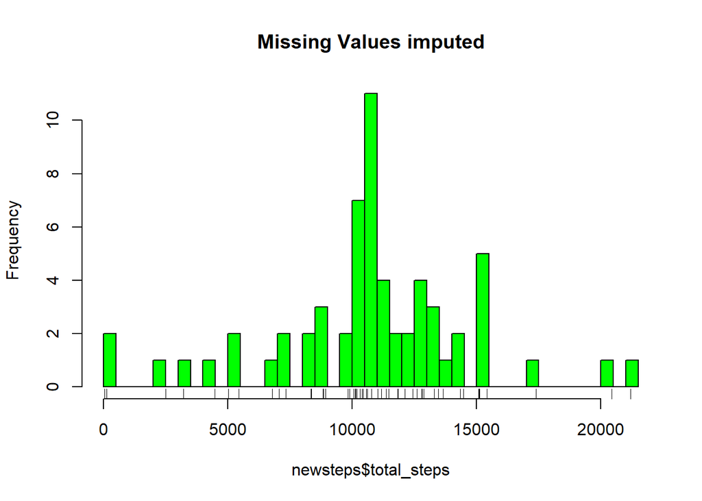

```r
       hist(newsteps$total_steps, col="green", breaks = 50, main="Missing Values imputed")
       rug(newsteps$total_steps)
```

```r
    newmean <- summarize(newsteps, mean= mean(total_steps))
    newmedian<- summarize(newsteps, median= median(total_steps))
```

Do these values differ from the estimates from the first part of the assignment?

What is the impact of imputing missing data on the estimates of the total daily number of steps?

# Are there differences in activity patterns between weekdays and weekends?

Create a dataset for analysis, using the filled-in data.

```r
    weekdata<-  mutate(newdata, weekday=wday(date, label=TRUE))
          newdata$date <-ymd(as.character(newdata$date))
           weekday <-filter(weekdata, weekday=="Mon"|weekday=="Tue"
                       |weekday=="Wed"|weekday=="Thu"|weekday=="Fri")

            steps_weekday  <- group_by(weekday, interval)
      avg_weekday <- summarize(steps_weekday, avg_steps = mean(steps))
           avg_weekday<- mutate(avg_weekday, daytype="weekday")

      weekend <- filter(weekdata, weekday=="Sat"|weekday=="Sun")
      steps_weekend  <- group_by(weekend, interval)
      avg_weekend <- summarize(steps_weekend, avg_steps = mean(steps))
            avg_weekend<- mutate(avg_weekend, daytype="weekend")
      ### Create data set for plot
      plotdata <- rbind (avg_weekend, avg_weekday)
```

```
  Here is a panel plot containing a time series plot of the 5-minute interval (x-axis)
  and the average number of steps taken across all weekday days or weekend days (y-axis).
```

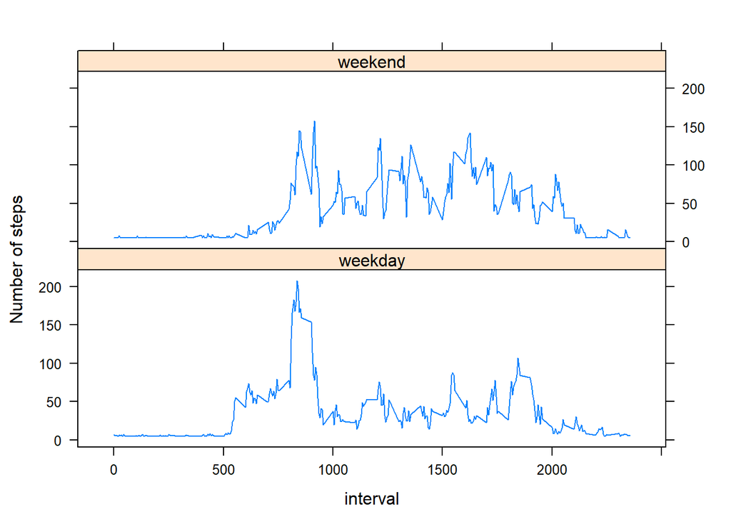

```r
      xyplot(avg_steps ~ interval | as.factor(daytype), data= plotdata, type ="l",
             ylab="Number of steps",layout = c(1,2))
```